# Lista Analise Fatorial

Davi Wentrick Feijó

2023-06-22

### 9.1)

Mostre que a matriz de covriancia $\rho$:

```
##      [,1] [,2] [,3]
## [1,] 1.00 0.63 0.45
## [2,] 0.63 1.00 0.35
## [3,] 0.45 0.35 1.00
```

E a matriz de variancia dos erros $\Psi$

```
##      [,1] [,2] [,3]
## [1,] 0.19 0.00 0.00
## [2,] 0.00 0.51 0.00
## [3,] 0.00 0.00 0.75
```

Escreva $\rho$ na forma $\rho = LL^T + \Psi$

Para isso primeiro vamos encontrar a matriz $LL^T$

```r
LLT = p - psi #diagonais contem a comunalidade
LLT
```

```
##      [,1] [,2] [,3]
## [1,] 0.81 0.63 0.45
## [2,] 0.63 0.49 0.35
## [3,] 0.45 0.35 0.25
```

Agora podemos reconstruir a matriz na forma desejada

```r
p_construido = LLT + psi
p_construido
```

```
##      [,1] [,2] [,3]
## [1,] 1.00 0.63 0.45
## [2,] 0.63 1.00 0.35
## [3,] 0.45 0.35 1.00
```

### 9.2)

#### a)

```r
comuna = diag(LLT)
comuna
```

```
## [1] 0.81 0.49 0.25
```

#### b)

```r
#cor_xf = Lestimado[1]/(1*comu[1])
```

### 9.3)

Para calcular a pelo metodo de PCA precisamos encontrar os autovalores e autovetores da matriz $\rho$

```r
eigen_p = eigen(p)

autoval <- eigen_p$values

autovet <- eigen_p$vectors
```

Sabemos que a matriz diagonal D contem a $\sqrt{\lambda_i}$ ou seja a raiz dos autovalores

```r
D <- matrix(0, nrow = 3, ncol = 3)
diag(D) <- sqrt(autoval)
```

Podemos encontrar a matriz L por meio de $L = e_i \cdot \sqrt{\lambda_i}$, ou seja é a multiplicacao da matriz contendo os autovetores pela matriz diagonal com a raiz dos autovalores

```r
Lestimado <- (autovet%*%D)[,1]
LTestimado <- t(Lestimado)
```

E assim podemos finalmente obter nossa matriz $LL^T$

```r
LLT <- Lestimado%*%LTestimado
LLT
```

```
##           [,1]      [,2]      [,3]
## [1,] 0.7669140 0.7278302 0.6227161
## [2,] 0.7278302 0.6907382 0.5909810
## [3,] 0.6227161 0.5909810 0.5056308
```

Sabemos que a comunalidade $\hat{h^2}$ pode ser obtida como $\hat{h^2} = L^2$

```r
comu <- Lestimado^2
comu
```

```
## [1] 0.7669140 0.6907382 0.5056308
```

A matriz de variancia dos erros pode ser obtida realizando $\hat\Psi = \Sigma - LL^T$

```r
psiestimado <- diag(p-LLT)
psiestimado
```

```
## [1] 0.2330860 0.3092618 0.4943692
```

Podemos obter a matriz de residuos fazendo $\Sigma - \hat\Sigma$

```r
residuo = p - (LLT+psi)
```

Calculo da variancia explicada pelos autovalores

```r
var_explained = autoval/sum(autoval)
var_explained
```

```
## [1] 0.6544277 0.2264977 0.1190746
```

Podemos verificar tudo isso rodando a funcao que faz a analise fatorial com 1 fator

```r
principal(p, nfactors = 1, rotate = 'none',covar = TRUE)
```

```
## Principal Components Analysis
## Call: principal(r = p, nfactors = 1, rotate = "none", covar = TRUE)
## Standardized loadings (pattern matrix) based upon correlation matrix
##    PC1   h2   u2 com
## 1 0.88 0.77 0.23   1
## 2 0.83 0.69 0.31   1
## 3 0.71 0.51 0.49   1
##
##                 PC1
## SS loadings    1.96
## Proportion Var 0.65
##
## Mean item complexity =  1
## Test of the hypothesis that 1 component is sufficient.
##
## The root mean square of the residuals (RMSR) is  0.18
##
## Fit based upon off diagonal values = 0.86
```

obs: Como estamos com 1 fator usamos para os calculos a primeira componente, ou seja somente o primeiro autovetor e autovalor.

### 9.14) Reproducao do exemplo 9.14 do livro

Vamos obter a partir da seguinte matriz de correlacao (Chicken-Bone Data) a analise fatoria pelo metodo das Componentes Principais e Maximo Verossimilhanca

```r
variable_names <- c("Skull Length", "Skull Breadth", "Femur Length", "Tibia Length", "Humerus Length", "Ulna Length")


R = matrix(c(1.000, 0.505, 0.569, 0.602, 0.621, 0.603,
             0.505, 1.000, 0.422, 0.467, 0.482, 0.450,
             0.569, 0.422, 1.000, 0.926, 0.877, 0.878,
             0.602, 0.467, 0.926, 1.000, 0.874, 0.894,
             0.621, 0.482, 0.877, 0.874, 1.000, 0.937,
             0.603, 0.450, 0.878, 0.894, 0.937, 1.000),ncol = 6)

colnames(R) <- variable_names
rownames(R) <- variable_names
```

Analise Fatorial PCA

```r
AF_prin = principal(R, nfactors = 3, rotate = 'none',
                    covar = TRUE)

print(AF_prin, digits=3, cutoff=.0003)
```

```
## Principal Components Analysis
## Call: principal(r = R, nfactors = 3, rotate = "none", covar = TRUE)
## Standardized loadings (pattern matrix) based upon correlation matrix
##                  PC1    PC2    PC3    h2       u2  com
## Skull Length   0.741  0.350  0.573 0.999 0.000506 2.36
## Skull Breadth  0.604  0.721 -0.340 1.000 0.000184 2.40
## Femur Length   0.929 -0.233 -0.075 0.923 0.077498 1.14
## Tibia Length   0.943 -0.174 -0.067 0.925 0.075102 1.08
## Humerus Length 0.948 -0.143 -0.045 0.920 0.079666 1.05
## Ulna Length    0.945 -0.189 -0.047 0.930 0.069761 1.08
##
##                         PC1   PC2   PC3
## SS loadings           4.456 0.782 0.458
## Proportion Var        0.743 0.130 0.076
## Cumulative Var        0.743 0.873 0.950
## Proportion Explained  0.782 0.137 0.080
## Cumulative Proportion 0.782 0.920 1.000
##
## Mean item complexity =  1.5
## Test of the hypothesis that 3 components are sufficient.
##
## The root mean square of the residuals (RMSR) is  0.022
##
## Fit based upon off diagonal values = 0.999
```

```r
AF_prin$communality
```

```
##   Skull Length  Skull Breadth   Femur Length   Tibia Length Humerus Length
##      0.9994939      0.9998164      0.9225019      0.9248977      0.9203343
##    Ulna Length
##      0.9302392
```

```r
round(AF_prin$uniquenesses,2)
```

```
##   Skull Length  Skull Breadth   Femur Length   Tibia Length Humerus Length
##           0.00           0.00           0.08           0.08           0.08
##    Ulna Length
##           0.07
```

```r
AF_prin$loadings
```

```
##
## Loadings:
##                PC1    PC2    PC3
## Skull Length    0.741  0.350  0.573
## Skull Breadth   0.604  0.721 -0.340
## Femur Length    0.929 -0.233
## Tibia Length    0.943 -0.174
## Humerus Length  0.948 -0.143
## Ulna Length     0.945 -0.189
##
##                  PC1   PC2   PC3
## SS loadings    4.456 0.782 0.458
## Proportion Var 0.743 0.130 0.076
## Cumulative Var 0.743 0.873 0.950
```

Analise Fatorial EMV

```r
AF_EMV = factanal(covmat = R, factors = 3, rotation = "none")

print(AF_EMV, digits=3, cutoff=.0003)
```

```
##
## Call:
## factanal(factors = 3, covmat = R, rotation = "none")
##
## Uniquenesses:
##   Skull Length  Skull Breadth   Femur Length   Tibia Length Humerus Length
##          0.512          0.317          0.117          0.005          0.019
##    Ulna Length
##          0.088
##
## Loadings:
##                Factor1 Factor2 Factor3
## Skull Length    0.622   0.284   0.143
## Skull Breadth   0.484   0.660   0.121
## Femur Length    0.937  -0.056   0.038
## Tibia Length    0.992          -0.105
## Humerus Length  0.920  -0.011   0.367
## Ulna Length     0.926  -0.037   0.232
##
##                Factor1 Factor2 Factor3
## SS loadings      4.187   0.520   0.236
## Proportion Var   0.698   0.087   0.039
## Cumulative Var   0.698   0.784   0.824
##
## The degrees of freedom for the model is 0 and the fit was 8e-04
```

```r
round(AF_EMV$uniquenesses,2)
```

```
##   Skull Length  Skull Breadth   Femur Length   Tibia Length Humerus Length
##           0.51           0.32           0.12           0.00           0.02
##    Ulna Length
##           0.09
```

```r
AF_EMV$loadings
```

```
##
## Loadings:
##                Factor1 Factor2 Factor3
## Skull Length    0.622   0.284   0.143
## Skull Breadth   0.484   0.660   0.121
## Femur Length    0.937
## Tibia Length    0.992          -0.105
## Humerus Length  0.920           0.367
## Ulna Length     0.926           0.232
##
##                Factor1 Factor2 Factor3
## SS loadings      4.187   0.520   0.236
## Proportion Var   0.698   0.087   0.039
## Cumulative Var   0.698   0.784   0.824
```

Gráfico dos agrupamentos

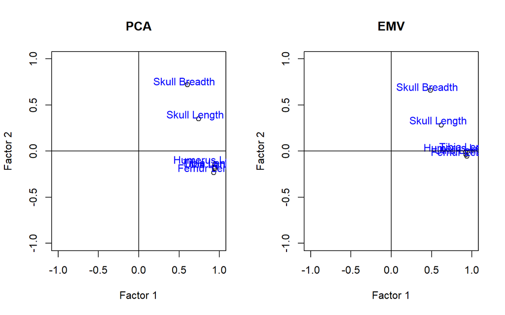

### 9.6)

### 9.10)

Usando os dados da Matriz de correlacao do exemplo 9.14 (Chicken-Bone Data)

#### a) Variancia especifica $(\Psi)$

```r
LLT = AF_EMV$loadings %*% t(AF_EMV$loadings)
psi = diag(R - LLT)
psi
```

```
##   Skull Length  Skull Breadth   Femur Length   Tibia Length Humerus Length
##    0.512249587    0.316600515    0.116597161    0.004999278    0.019024316
##    Ulna Length
##    0.087965254
```

#### b) As Comunalidades $(h^2)$

```r
comu = LLT^2
comu
```

```
##                Skull Length Skull Breadth Femur Length Tibia Length
## Skull Length      0.2379005     0.2551077    0.3279611    0.3623609
## Skull Breadth     0.2551077     0.4670349    0.1773379    0.2180929
## Femur Length      0.3279611     0.1773379    0.7804006    0.8574467
## Tibia Length      0.3623609     0.2180929    0.8574467    0.9900264
## Humerus Length    0.3862777     0.2321636    0.7688774    0.7638817
## Ulna Length       0.3581998     0.2037189    0.7720473    0.7992129
##                Humerus Length Ulna Length
## Skull Length        0.3862777   0.3581998
## Skull Breadth       0.2321636   0.2037189
## Femur Length        0.7688774   0.7720473
## Tibia Length        0.7638817   0.7992129
## Humerus Length      0.9623133   0.8779937
## Ulna Length         0.8779937   0.8318074
```

#### c) Proporcao da variancia explicada por cada fator

```r
eigen_r = eigen(R)

autoval <- eigen_r$values

autovet <- eigen_r$vectors

var_explained = autoval/sum(autoval)
var_explained
```

```
## [1] 0.742741417 0.130401652 0.076404177 0.028138761 0.013181290 0.009132703
```

#### d) A matriz de residuos

```r
residuos = R - (LLT+psi)
residuos
```

```
##                Skull Length Skull Breadth Femur Length Tibia Length
## Skull Length     0.00000000  -0.512331443 -0.515928493  -0.51221376
## Skull Breadth   -0.31668237   0.000000000 -0.315715561  -0.31660471
## Femur Length    -0.12027607  -0.115712207  0.000000000  -0.11658132
## Tibia Length    -0.00496345  -0.005003475 -0.004983441   0.00000000
## Humerus Length  -0.01953671  -0.018857876 -0.018880887  -0.01902757
## Ulna Length     -0.08346318  -0.089317520 -0.088627504  -0.08795232
##                Humerus Length  Ulna Length
## Skull Length     -0.512761977 -0.507747508
## Skull Breadth    -0.316434075 -0.317952781
## Femur Length     -0.116453731 -0.117259411
## Tibia Length     -0.005002532 -0.004986341
## Humerus Length    0.000000000 -0.019037517
## Ulna Length      -0.087978454  0.000000000
```

### 9.19)

```r
names = c("sales_growth","sales_profitability","new_account_sales","creativity_test","mechanical_reasoning_test","abstract_reasoning_test","mathematics_test")
data <- read_excel("table9_12-SalespeopleData.xlsx",
                   col_names = names, col_types = c("numeric",
                                                    "numeric", "numeric", "numeric",
                                                    "numeric", "numeric", "numeric"))
cor_data = cor(as.matrix(data))
```

#### a)

```r
AF2 <- principal(cor_data, nfactors = 2, rotate = 'none', covar = T,n.obs = 50)
AF3 <- principal(cor_data, nfactors = 3, rotate = 'none', covar = T,n.obs = 50)
```

```r
AF2
```

```
## Principal Components Analysis
## Call: principal(r = cor_data, nfactors = 2, rotate = "none", n.obs = 50,
##     covar = T)
## Standardized loadings (pattern matrix) based upon correlation matrix
##                            PC1   PC2   h2    u2 com
## sales_growth              0.97 -0.11 0.96 0.041 1.0
## sales_profitability       0.94  0.03 0.89 0.110 1.0
## new_account_sales         0.94  0.01 0.89 0.107 1.0
## creativity_test           0.66  0.65 0.85 0.147 2.0
## mechanical_reasoning_test 0.78  0.28 0.69 0.305 1.3
## abstract_reasoning_test   0.65 -0.62 0.81 0.194 2.0
## mathematics_test          0.91 -0.19 0.87 0.127 1.1
##
##                        PC1  PC2
## SS loadings           5.03 0.93
## Proportion Var        0.72 0.13
## Cumulative Var        0.72 0.85
## Proportion Explained  0.84 0.16
## Cumulative Proportion 0.84 1.00
##
## Mean item complexity =  1.3
## Test of the hypothesis that 2 components are sufficient.
##
## The root mean square of the residuals (RMSR) is  0.08
##  with the empirical chi square  11.93  with prob <  0.15
##
## Fit based upon off diagonal values = 0.99
```

```r
AF3
```

```
## Principal Components Analysis
## Call: principal(r = cor_data, nfactors = 3, rotate = "none", n.obs = 50,
##     covar = T)
## Standardized loadings (pattern matrix) based upon correlation matrix
##                            PC1   PC2   PC3   h2    u2 com
## sales_growth              0.97 -0.11 -0.05 0.96 0.039 1.0
## sales_profitability       0.94  0.03 -0.31 0.99 0.013 1.2
## new_account_sales         0.94  0.01  0.14 0.91 0.087 1.0
## creativity_test           0.66  0.65  0.32 0.95 0.045 2.4
## mechanical_reasoning_test 0.78  0.28  0.00 0.69 0.305 1.3
## abstract_reasoning_test   0.65 -0.62  0.43 0.99 0.012 2.7
## mathematics_test          0.91 -0.19 -0.31 0.97 0.033 1.3
##
##                        PC1  PC2  PC3
## SS loadings           5.03 0.93 0.50
## Proportion Var        0.72 0.13 0.07
## Cumulative Var        0.72 0.85 0.92
## Proportion Explained  0.78 0.14 0.08
## Cumulative Proportion 0.78 0.92 1.00
##
## Mean item complexity =  1.6
## Test of the hypothesis that 3 components are sufficient.
##
## The root mean square of the residuals (RMSR) is  0.04
##  with the empirical chi square  3.95  with prob <  0.27
##
## Fit based upon off diagonal values = 1
```

#### b)

```r
AF2_rotated <- principal(cor_data, nfactors = 2, rotate = 'varimax', covar = T,n.obs = 50)
AF3_rotated <- principal(cor_data, nfactors = 3, rotate = 'varimax', covar = T,n.obs = 50)
```

```r
AF2_rotated
```

```
## Principal Components Analysis
## Call: principal(r = cor_data, nfactors = 2, rotate = "varimax", n.obs = 50,
##     covar = T)
## Standardized loadings (pattern matrix) based upon correlation matrix
##                            RC1   RC2   h2    u2 com
## sales_growth              0.79  0.58 0.96 0.041 1.8
## sales_profitability       0.67  0.66 0.89 0.110 2.0
## new_account_sales         0.68  0.65 0.89 0.107 2.0
## creativity_test           0.04  0.92 0.85 0.147 1.0
## mechanical_reasoning_test 0.38  0.74 0.69 0.305 1.5
## abstract_reasoning_test   0.90 -0.01 0.81 0.194 1.0
## mathematics_test          0.80  0.48 0.87 0.127 1.6
##
##                        RC1  RC2
## SS loadings           3.13 2.84
## Proportion Var        0.45 0.41
## Cumulative Var        0.45 0.85
## Proportion Explained  0.52 0.48
## Cumulative Proportion 0.52 1.00
##
## Mean item complexity =  1.6
## Test of the hypothesis that 2 components are sufficient.
##
## The root mean square of the residuals (RMSR) is  0.08
##  with the empirical chi square  11.93  with prob <  0.15
##
## Fit based upon off diagonal values = 0.99
```

```r
AF3_rotated
```

```
## Principal Components Analysis
## Call: principal(r = cor_data, nfactors = 3, rotate = "varimax", n.obs = 50,
##     covar = T)
## Standardized loadings (pattern matrix) based upon correlation matrix
##                            RC1  RC2  RC3   h2    u2 com
## sales_growth              0.78 0.39 0.45 0.96 0.039 2.1
## sales_profitability       0.91 0.36 0.19 0.99 0.013 1.4
## new_account_sales         0.62 0.55 0.48 0.91 0.087 2.9
## creativity_test           0.21 0.95 0.05 0.95 0.045 1.1
## mechanical_reasoning_test 0.55 0.61 0.15 0.69 0.305 2.1
## abstract_reasoning_test   0.29 0.06 0.95 0.99 0.012 1.2
## mathematics_test          0.91 0.18 0.33 0.97 0.033 1.3
##
##                        RC1  RC2  RC3
## SS loadings           3.07 1.89 1.51
## Proportion Var        0.44 0.27 0.22
## Cumulative Var        0.44 0.71 0.92
## Proportion Explained  0.48 0.29 0.23
## Cumulative Proportion 0.48 0.77 1.00
##
## Mean item complexity =  1.7
## Test of the hypothesis that 3 components are sufficient.
##
## The root mean square of the residuals (RMSR) is  0.04
##  with the empirical chi square  3.95  with prob <  0.27
##
## Fit based upon off diagonal values = 1
```

#### c)

Vamos calcular a comunalidade, variancia especifica, a matriz $LL^T$ e a matriz de residuos para m=2

```r
L = AF2$loadings #nao sai o resultado correto
AF2_comu = AF2$communality
AF2_psi = diag(AF2$uniquenesses)
AF2_LLT = L %*% t(L)
resAF2 <- round(cor(data) - AF2_LLT - AF2_psi,3)
```

```r
AF2_comu
```

```
##              sales_growth       sales_profitability         new_account_sales
##                 0.9585223                 0.8898072                 0.8926324
##           creativity_test mechanical_reasoning_test   abstract_reasoning_test
##                 0.8530944                 0.6947511                 0.8061954
##          mathematics_test
##                 0.8731112
```

```r
AF2_psi
```

```
##            [,1]      [,2]      [,3]      [,4]      [,5]      [,6]      [,7]
## [1,] 0.04147769 0.0000000 0.0000000 0.0000000 0.0000000 0.0000000 0.0000000
## [2,] 0.00000000 0.1101928 0.0000000 0.0000000 0.0000000 0.0000000 0.0000000
## [3,] 0.00000000 0.0000000 0.1073676 0.0000000 0.0000000 0.0000000 0.0000000
## [4,] 0.00000000 0.0000000 0.0000000 0.1469056 0.0000000 0.0000000 0.0000000
## [5,] 0.00000000 0.0000000 0.0000000 0.0000000 0.3052489 0.0000000 0.0000000
## [6,] 0.00000000 0.0000000 0.0000000 0.0000000 0.0000000 0.1938046 0.0000000
## [7,] 0.00000000 0.0000000 0.0000000 0.0000000 0.0000000 0.0000000 0.1268888
```

```r
AF2_LLT
```

```
##                           sales_growth sales_profitability new_account_sales
## sales_growth                 0.9585223           0.9144237         0.9183475
## sales_profitability          0.9144237           0.8898072         0.8910297
## new_account_sales            0.9183475           0.8910297         0.8926324
## creativity_test              0.5728018           0.6408686         0.6295764
## mechanical_reasoning_test    0.7314249           0.7466052         0.7425467
## abstract_reasoning_test      0.6983724           0.5942005         0.6074644
## mathematics_test             0.9104147           0.8564286         0.8619032
##                           creativity_test mechanical_reasoning_test
## sales_growth                   0.57280177                 0.7314249
## sales_profitability            0.64086858                 0.7466052
## new_account_sales              0.62957641                 0.7425467
## creativity_test                0.85309438                 0.7012578
## mechanical_reasoning_test      0.70125775                 0.6947511
## abstract_reasoning_test        0.02760441                 0.3313525
## mathematics_test               0.47859044                 0.6608599
##                           abstract_reasoning_test mathematics_test
## sales_growth                           0.69837236        0.9104147
## sales_profitability                    0.59420052        0.8564286
## new_account_sales                      0.60746435        0.8619032
## creativity_test                        0.02760441        0.4785904
## mechanical_reasoning_test              0.33135247        0.6608599
## abstract_reasoning_test                0.80619543        0.7132694
## mathematics_test                       0.71326939        0.8731112
```

```r
resAF2
```

```
##                           sales_growth sales_profitability new_account_sales
## sales_growth                     0.000               0.012            -0.034
## sales_profitability              0.012               0.000            -0.049
## new_account_sales               -0.034              -0.049             0.000
## creativity_test                 -0.001              -0.099             0.071
## mechanical_reasoning_test       -0.023              -0.001            -0.105
## abstract_reasoning_test         -0.024              -0.129             0.034
## mathematics_test                 0.017               0.088            -0.009
##                           creativity_test mechanical_reasoning_test
## sales_growth                       -0.001                    -0.023
## sales_profitability                -0.099                    -0.001
## new_account_sales                   0.071                    -0.105
## creativity_test                     0.000                    -0.111
## mechanical_reasoning_test          -0.111                     0.000
## abstract_reasoning_test             0.119                     0.055
## mathematics_test                   -0.066                    -0.086
##                           abstract_reasoning_test mathematics_test
## sales_growth                               -0.024            0.017
## sales_profitability                        -0.129            0.088
## new_account_sales                           0.034           -0.009
## creativity_test                             0.119           -0.066
## mechanical_reasoning_test                   0.055           -0.086
## abstract_reasoning_test                     0.000           -0.147
## mathematics_test                           -0.147            0.000
```

Vamos calcular a comunalidade, variancia especifica, a matriz $LL^T$ e a matriz de residuos para m=3

```r
AF3_comu = AF3$loadings^3
AF3_psi = diag(AF3$uniquenesses)
AF3_LLT = AF3$loadings %*% t(AF3$loadings)
resAF3 <- round(cor(data) - AF3_LLT - AF3_psi,3)
```

```r
AF3_comu
```

```
##
## Loadings:
##                           PC1    PC2    PC3
## sales_growth               0.921
## sales_profitability        0.838
## new_account_sales          0.843
## creativity_test            0.288  0.269
## mechanical_reasoning_test  0.481
## abstract_reasoning_test    0.273 -0.239
## mathematics_test           0.764
##
##                  PC1   PC2   PC3
## SS loadings    3.235 0.130 0.009
## Proportion Var 0.462 0.019 0.001
## Cumulative Var 0.462 0.481 0.482
```

```r
AF3_psi
```

```
##            [,1]       [,2]       [,3]     [,4]      [,5]       [,6]       [,7]
## [1,] 0.03864028 0.00000000 0.00000000 0.000000 0.0000000 0.00000000 0.00000000
## [2,] 0.00000000 0.01270628 0.00000000 0.000000 0.0000000 0.00000000 0.00000000
## [3,] 0.00000000 0.00000000 0.08660774 0.000000 0.0000000 0.00000000 0.00000000
## [4,] 0.00000000 0.00000000 0.00000000 0.045407 0.0000000 0.00000000 0.00000000
## [5,] 0.00000000 0.00000000 0.00000000 0.000000 0.3052315 0.00000000 0.00000000
## [6,] 0.00000000 0.00000000 0.00000000 0.000000 0.0000000 0.01228801 0.00000000
## [7,] 0.00000000 0.00000000 0.00000000 0.000000 0.0000000 0.00000000 0.03308555
```

```r
AF3_LLT
```

```
##                           sales_growth sales_profitability new_account_sales
## sales_growth                 0.9613597           0.9310552         0.9106726
## sales_profitability          0.9310552           0.9872937         0.8460429
## new_account_sales            0.9106726           0.8460429         0.9133923
## creativity_test              0.5558314           0.5413962         0.6754796
## mechanical_reasoning_test    0.7312023           0.7453005         0.7431488
## abstract_reasoning_test      0.6756780           0.4611764         0.6688506
## mathematics_test             0.9267290           0.9520558         0.8177744
##                           creativity_test mechanical_reasoning_test
## sales_growth                    0.5558314                 0.7312023
## sales_profitability             0.5413962                 0.7453005
## new_account_sales               0.6754796                 0.7431488
## creativity_test                 0.9545930                 0.7025890
## mechanical_reasoning_test       0.7025890                 0.6947685
## abstract_reasoning_test         0.1633383                 0.3331328
## mathematics_test                0.3810153                 0.6595801
##                           abstract_reasoning_test mathematics_test
## sales_growth                            0.6756780        0.9267290
## sales_profitability                     0.4611764        0.9520558
## new_account_sales                       0.6688506        0.8177744
## creativity_test                         0.1633383        0.3810153
## mechanical_reasoning_test               0.3331328        0.6595801
## abstract_reasoning_test                 0.9877120        0.5827824
## mathematics_test                        0.5827824        0.9669145
```

```r
resAF3
```

```
##                           sales_growth sales_profitability new_account_sales
## sales_growth                     0.000              -0.005            -0.027
## sales_profitability             -0.005               0.000            -0.004
## new_account_sales               -0.027              -0.004             0.000
## creativity_test                  0.016               0.000             0.025
## mechanical_reasoning_test       -0.023               0.001            -0.106
## abstract_reasoning_test         -0.001               0.004            -0.028
## mathematics_test                 0.001              -0.008             0.035
##                           creativity_test mechanical_reasoning_test
## sales_growth                        0.016                    -0.023
## sales_profitability                 0.000                     0.001
## new_account_sales                   0.025                    -0.106
## creativity_test                     0.000                    -0.112
## mechanical_reasoning_test          -0.112                     0.000
## abstract_reasoning_test            -0.016                     0.053
## mathematics_test                    0.032                    -0.085
##                           abstract_reasoning_test mathematics_test
## sales_growth                               -0.001            0.001
## sales_profitability                         0.004           -0.008
## new_account_sales                          -0.028            0.035
## creativity_test                            -0.016            0.032
## mechanical_reasoning_test                   0.053           -0.085
## abstract_reasoning_test                     0.000           -0.016
## mathematics_test                           -0.016            0.000
```

#### d)

```r
#m=2
dim(AF2$loadings)
```

```
## [1] 7 2
```

```r
n = dim(data)[1]
p = dim(AF2$loadings)[1]
m = dim(AF2$loadings)[2]

AF2_teste_stat = AF2$chi
AF2_pvalue = AF2$PVAL
```

```
## A estatistica do teste é: 11.9336
```

```
## O p-valor obtido foi: 9.682959e-32
```

```r
#m=3
dim(AF3$loadings)
```

```
## [1] 7 3
```

```r
n = dim(data)[1]
p = dim(AF3$loadings)[1]
m = dim(AF3$loadings)[2]

AF3_teste_stat = AF3$chi
AF3_pvalue = AF3$PVAL
```

```
## A estatistica do teste é: 3.946427
```

```
## O p-valor obtido foi: 3.703147e-17
```

### 9.21)

Primieras observacoes (head) dos dados de analise (Air Polution Data)

```
##      wind solar_radiation CO NO NO2 O3 HC
## [1,]    8              98  7  2  12  8  2
## [2,]    7             107  4  3   9  5  3
## [3,]    7             103  4  3   5  6  3
## [4,]   10              88  5  2   8 15  4
## [5,]    6              91  4  2   8 10  3
## [6,]    8              90  5  2  12 12  4
```

Matriz de covariancia

```r
S_cov = cov(dados)
S_cov
```

```
##                       wind solar_radiation         CO         NO        NO2
## wind             2.5000000      -2.7804878 -0.3780488 -0.4634146 -0.5853659
## solar_radiation -2.7804878     300.5156794  3.9094077 -1.3867596  6.7630662
## CO              -0.3780488       3.9094077  1.5220674  0.6736353  2.3147503
## NO              -0.4634146      -1.3867596  0.6736353  1.1823461  1.0882695
## NO2             -0.5853659       6.7630662  2.3147503  1.0882695 11.3635308
## O3              -2.2317073      30.7909408  2.8217189 -0.8106852  3.1265970
## HC               0.1707317       0.6236934  0.1416957  0.1765389  1.0441347
##                         O3        HC
## wind            -2.2317073 0.1707317
## solar_radiation 30.7909408 0.6236934
## CO               2.8217189 0.1416957
## NO              -0.8106852 0.1765389
## NO2              3.1265970 1.0441347
## O3              30.9785134 0.5946574
## HC               0.5946574 0.4785134
```

```r
AF_prin = principal(S_cov, nfactors = 2, rotate = 'none',
                    covar = TRUE)

round(AF_prin$uniquenesses,2)
```

```
##            wind solar_radiation              CO              NO             NO2
##            2.31            0.00            1.18            1.17           10.55
##              O3              HC
##            0.34            0.46
```

```r
AF_prin$loadings
```

```
##
## Loadings:
##                 PC1    PC2
## wind            -0.175 -0.405
## solar_radiation 17.324 -0.618
## CO               0.245  0.529
## NO
## NO2              0.423  0.800
## O3               1.961  5.176
## HC                      0.127
##
##                    PC1    PC2
## SS loadings    304.258 28.276
## Proportion Var  43.465  4.039
## Cumulative Var  43.465 47.505
```

```r
AF_EMV = factanal(covmat = S_cov, factors = 2, rotation = "none")

round(AF_EMV$uniquenesses,2)
```

```
##            wind solar_radiation              CO              NO             NO2
##            0.91            0.90            0.21            0.50            0.61
##              O3              HC
##            0.00            0.92
```

```r
AF_EMV$loadings
```

```
##
## Loadings:
##                 Factor1 Factor2
## wind            -0.168  -0.255
## solar_radiation          0.321
## CO               0.783   0.418
## NO               0.697  -0.128
## NO2              0.597   0.173
## O3                       0.997
## HC               0.246   0.156
##
##                Factor1 Factor2
## SS loadings      1.544   1.408
## Proportion Var   0.221   0.201
## Cumulative Var   0.221   0.422
```

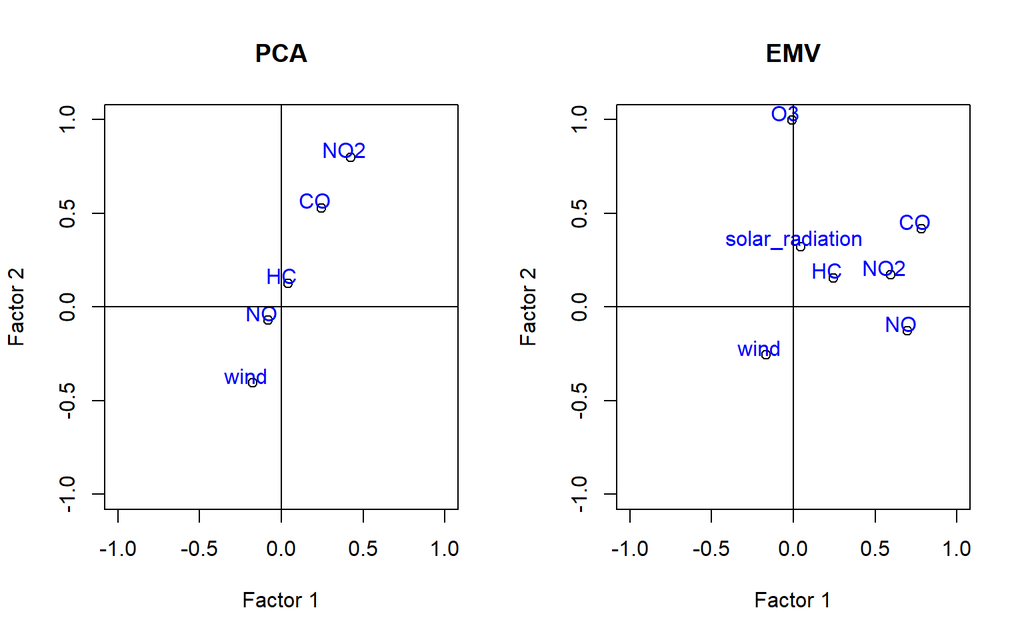

### 9.22)

```r
AF_EMV_regression = factanal(x = dados, factors = 2, rotation = "none",scores = "regression")
head(AF_EMV_regression$scores)
```

```
##          Factor1    Factor2
## [1,]  1.37594214 -0.2291942
## [2,]  0.09278943 -0.7870523
## [3,] -0.16999889 -0.6108918
## [4,] -0.18592875  1.0005435
## [5,] -0.44302587  0.1040915
## [6,]  0.22402630  0.4694878
```

```r
AF_EMV_least_squares = factanal(x = dados, factors = 2, rotation = "none", scores = "Bartlett")
head(AF_EMV_least_squares$scores)
```

```
##         Factor1    Factor2
## [1,]  1.6786725 -0.2303396
## [2,]  0.1132047 -0.7909856
## [3,] -0.2074015 -0.6139447
## [4,] -0.2268362  1.0055436
## [5,] -0.5404990  0.1046117
## [6,]  0.2733158  0.4718341
```

[figure not shown]

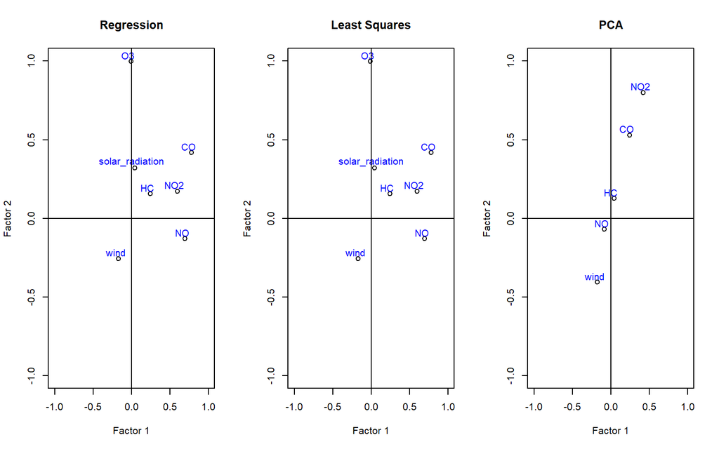

```r
AF_prin = principal(S_cov, nfactors = 2, rotate = 'none', covar=TRUE, scores=TRUE)
head(AF_prin$scores)
```

[output not shown]

### 9.23)

### 9.25)